[OHI British Columbia](http://www.ohibc.org/) | [OHI Science](http://ohi-science.org) | [Citation policy](https://github.com/OHI-Science/ohiprep/releases)

# OHIBC goal prep: Lasting Special Places

Compiled on Fri Jan 13 14:30:22 2017 by ohara

```r
knitr::opts_chunk$set(fig.width = 6, fig.height = 4, fig.path = 'Figs/',
                      echo = TRUE, message = FALSE, warning = FALSE)

library(sp)        # the classes and methods that make up spatial ops in R
# library(gdalUtils) # for gdal_rasterize() function
library(maptools)  # tools for reading and manipulating spatial objects
library(rgeos)
library(rgdal)
library(raster)


dir_git  <- '~/github/ohibc'         ### set wd to work in Github OHIBC location
source(file.path(dir_git, 'src/R/common.R'))  ### an OHIBC specific version of common.R

scenario <- 'v2017'

dir_spatial <- file.path(dir_git, 'prep/spatial') ### github: general buffer region shapefiles
dir_goal    <- file.path(dir_git, 'prep/lsp', scenario)
dir_rast    <- file.path(dir_goal, 'raster')            ### goal-specific raster files are small

dir_anx <- file.path(dir_M, 'git-annex/bcprep')
dir_goal_anx <- file.path(dir_anx, 'lsp', scenario)  ### git-annex: goal-specific large files

### provenance tracking
library(provRmd); prov_setup()

source(file.path(dir_goal, 'lsp_fxns.R'))
source(file.path(dir_git, 'src/R/rast_tools.R'))

### set up the default BC projection to be BC Albers
p4s_bcalb <- c('bcalb' = '+init=epsg:3005')
```

# 1 Summary: OHIBC Lasting Special Places subgoal (Sense of Place)

The Lasting Special Places goal model is similar to the OHI Global model: a region’s status is based upon percent of protected area within a certain amount inland and percent of protected area within 3 nautical mile offshore buffer, compared to a reference point of 30% protected area. The major difference is that the inland zone for OHIBC will represent the coastal sub-watersheds, i.e. the sub-watersheds that intersect a 1 km inland buffer.

$$X_{LSP} = \frac{\frac{pA_{CMPA}}{pA_{refCMPA}} + \frac{pA_{CP}}{pA_{refCP}}}{2}$$

*pA* = percent of area within the inland or offshore buffer; *CMPA* = coastal marine protected area (3nm offshore); *CP* = coastline protected (coastal watersheds inland); and *refCMPA* = *refCP* = 30% reference point for both measures.

Future changes may incorporate other data sets and MaPP planning zones.

# 2 Data Sources

WDPA data base

# 3 Methods

## 3.1 Read in BC WDPA-MPA shapefile

We will create a BC-specific polygon subset of the WDPA global dataset, then rasterize to BC Albers at 500 m resolution.

```r
poly_wdpa_bc <- trim_wdpa_poly(p4s_bcalb, reload = FALSE)  ### defaults to BC Albers
```

## 3.2 Rasterize the BC WDPA-MPA shapefile and BC Parks, Ecological Reserves, and Protected Areas data

The PEP data does not seem to have year data, so WDPA will be the priority dataset. Create a total protected area raster in which values are year of protection, or 1 (or something similarly obvious) for areas protected under PEP but not under WDPA.

```r
# poly_hs_pep <- readOGR(dsn = file.path(dir_anx, '_raw_data/databc/TA_PEP_SVW'),
#                        layer = 'TA_PEP_SVW_polygon',
#                        stringsAsFactors = FALSE)
### checks out to BC Albers

rast_base <- raster(file.path(dir_spatial, 'raster/ohibc_rgn_raster_500m.tif'))

wdpa_bc_shp_file  <- file.path(dir_goal_anx, 'int', 'wdpa_bc_bcalb.shp')
wdpa_bc_rast_file <- file.path(dir_rast, 'rast_wdpa_bc_500m.tif')
pep_bc_shp_file  <- file.path(dir_anx, '_raw_data/databc/TA_PEP_SVW', 'TA_PEP_SVW_polygon.shp')
pep_bc_rast_file <- file.path(dir_rast, 'rast_pep_bc_500m.tif')
rast_prot_file <- file.path(dir_rast, 'rast_prot_500m.tif')

if(!file.exists(rast_prot_file)) {
  rast_wdpa <- gdal_rast2(src = wdpa_bc_shp_file,
                          rast_base = rast_base,
                          dst = wdpa_bc_rast_file,
                          value = 'STATUS_YR',
                          override_p4s = TRUE)

  rast_pep  <- gdal_rast2(src = pep_bc_shp_file,
                          rast_base = rast_base,
                          dst = pep_bc_rast_file,
                          value = 'OBJECTID', ### no year field available
                          override_p4s = TRUE)

  rast_prot <- rast_wdpa
  rast_prot[is.na(values(rast_prot)) & !is.na(values(rast_pep))] <- 1

  writeRaster(rast_prot, file.path(dir_rast, 'rast_prot_500m.tif'), overwrite = TRUE)

} else {

  git_prov(c(wdpa_bc_shp_file, pep_bc_shp_file), filetype = 'input')
  git_prov(rast_prot_file, filetype = 'output')

}
```

## 3.3 Set up coastal buffer rasters

Buffer shapefiles are located in `github/ohibc/prep/spatial`. Global LSP uses 1 km inland and 3nm offshore buffers, while resilience requires analysis over the entire EEZ. For OHI Howe Sound, we used the inland extent of the entire Squamish watershed. For OHIBC, we make a compromise: include coastal sub-watersheds that intersect with the 1 km buffer.

- Rasterize the watersheds using the value of watershed ID to 500 m
- Crosstabulate with the 500 m 1 km inland buffer to identify watersheds that intersect with the coastline
- create a raster of these features, with a rgn_id value to reflect the region ID with the greatest amount of overlap.

The buffer rasters are created in a separate .R script: ~/github/ohibc/prep/spatial/_rasterize_buffers.r.

### 3.3.1 Map of coastal buffers and protected area:

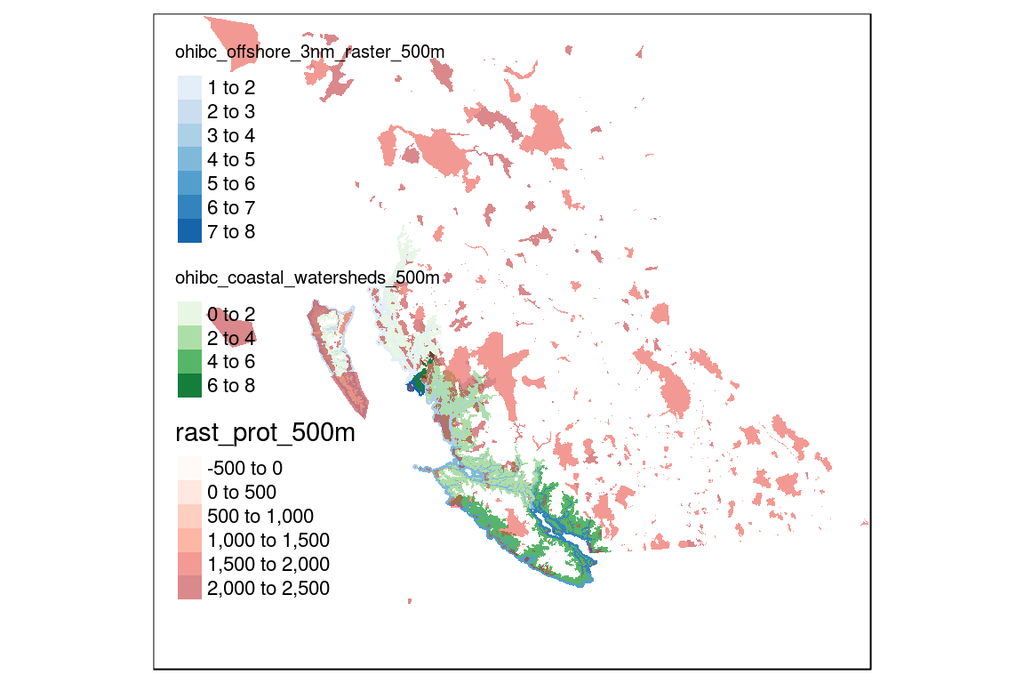

```r
library(tmap)
rast_3nm_file    <- file.path(dir_spatial, 'raster/ohibc_offshore_3nm_raster_500m.tif')
rast_inland_file <- file.path(dir_spatial, 'watershed/ohibc_coastal_watersheds_500m.tif')
rast_prot_file   <- file.path(dir_rast, 'rast_prot_500m.tif')

rast_3nm <- raster(rast_3nm_file)
rast_inland <- raster(rast_inland_file)
rast_prot <- raster(rast_prot_file)

rast_map <- tm_shape(rast_3nm, is.master = TRUE) +
    tm_raster(alpha = 1, palette = 'Blues') +
  tm_shape(rast_inland) +
    tm_raster(alpha = 1, palette = 'Greens') +
  tm_shape(rast_prot) +
    tm_raster(alpha = .5, palette = 'Reds')

print(rast_map)
```

# 4 Calculate goal model

```r
zonal_3nm_file <- file.path(dir_goal, 'int', 'zonal_stats_3nm.csv')
zonal_inland_file <- file.path(dir_goal, 'int', 'zonal_stats_inland.csv')

rast_3nm_file        <- file.path(dir_spatial, 'raster/ohibc_offshore_3nm_raster_500m.tif')
rast_inland_file <- file.path(dir_spatial, 'watershed/ohibc_coastal_watersheds_500m.tif')
rast_prot_file       <- file.path(dir_rast, 'rast_prot_500m.tif')

rast_3nm    <- raster(rast_3nm_file)
rast_inland <- raster(rast_inland_file)
rast_prot   <- raster(rast_prot_file)


### NOTE: The crosstab function returns this warning - does it affect the
### outcomes, or does the function coerce the correct outcome?
    # Warning message:
    # In FUN(X[[i]], ...) : integer overflow - use sum(as.numeric(.))

ptm <- proc.time()
stats_3nm <- raster::crosstab(rast_prot, rast_3nm, useNA = TRUE, progress = 'text') %>%
  as.data.frame() %>%
  setNames(c('year', 'rgn_id', 'n_cells')) %>%
  mutate(year   = as.integer(as.character(year)),
         rgn_id = as.integer(as.character(rgn_id))) %>%
  arrange(rgn_id, year)

stats_inland <- raster::crosstab(rast_prot, rast_inland, useNA = TRUE, progress = 'text') %>%
  as.data.frame() %>%
  setNames(c('year', 'rgn_id', 'n_cells')) %>%
  mutate(year   = as.integer(as.character(year)),
         rgn_id = as.integer(as.character(rgn_id))) %>%
  arrange(rgn_id, year)

message('Elapsed: ', (proc.time() - ptm)[3], ' sec')

write_csv(stats_3nm, zonal_3nm_file)
write_csv(stats_inland,  zonal_inland_file)
```

Once the WDPA raster is cross-tabulated against the OHI region rasters (both 3 nm offshore and 1 km inland) we have the number of protected cells, identified by year of protection, within each region. NA values are unprotected cells.

### 4.0.1 Summary of zonal stats dataframes (3 nm offshore):

```r
stats_3nm <- read_csv(zonal_3nm_file, nogit = TRUE)
print(summary(stats_3nm))
```

```
##       year          rgn_id         n_cells
##  Min.   :  -1   Min.   :1.000   Min.   :       0
##  1st Qu.:1947   1st Qu.:2.000   1st Qu.:       0
##  Median :1970   Median :4.000   Median :       0
##  Mean   :1945   Mean   :4.143   Mean   :   15217
##  3rd Qu.:1991   3rd Qu.:6.000   3rd Qu.:       1
##  Max.   :2013   Max.   :8.000   Max.   :10073059
##  NA's   :8      NA's   :89
```

### 4.0.2 Summary of zonal stats dataframes (coastal watersheds inland):

```r
stats_inland <- read_csv(zonal_inland_file, nogit = TRUE)
print(summary(stats_inland))
```

```
##       year          rgn_id         n_cells
##  Min.   :  -1   Min.   :1.000   Min.   :      0
##  1st Qu.:1947   1st Qu.:2.000   1st Qu.:      0
##  Median :1970   Median :4.000   Median :      0
##  Mean   :1945   Mean   :4.143   Mean   :  15217
##  3rd Qu.:1991   3rd Qu.:6.000   3rd Qu.:      4
##  Max.   :2013   Max.   :8.000   Max.   :9985614
##  NA's   :8      NA's   :89
```

## 4.1 Calculate protected area and total area by region

Grouping by rgn_id, the total number of cells per region is determined by summing cell counts across ALL years, including cells with year == NA (unprotected cells). We can then determine the protected area for each year by looking at the cumulative sum of cells up to any given year. Note that this step will also trim the dataframe to only instances since 1980 (though protected area pre-1980 is still counted).

Since the cells are 500 m on a side, we can easily calculate area by multiplying cell count * 0.25 km<sup>2</sup> per cell.

Finally we can calculate the status of a region for any given year by finding the ratio of protected:total and normalizing by the goal’s target of 30% protected area.

```r
lsp_thresh <- 0.30

rgn_names <- foreign::read.dbf(file.path(dir_spatial, 'ohibc_rgn.dbf'),
                               as.is = TRUE) %>%
  select(rgn_id, rgn_name)

stats_3nm <- read_csv(zonal_3nm_file, nogit = TRUE)
stats_inland  <- read_csv(zonal_inland_file, nogit = TRUE)

### Determine total cells per region (n_cells_tot) and then a cumulative
### total of cells per region
prot_inland <- stats_inland %>%
  group_by(rgn_id) %>%
  arrange(rgn_id, year) %>%
  mutate(n_cells_tot = sum(n_cells),
         n_cells_cum = cumsum(n_cells),
         a_tot_km2   = n_cells_tot / 4,
         a_prot_km2  = n_cells_cum / 4) %>%
  complete(year = full_seq(-1:2016, 1), nesting(rgn_id)) %>%
  fill(-year, -rgn_id, -n_cells) %>%
  filter(!is.na(rgn_id) & year >= 1980) %>%
  ungroup() %>%
  mutate(pct_prot   = round(n_cells_cum / n_cells_tot, 4),
         lsp_status = round(ifelse(pct_prot > lsp_thresh, 1, (pct_prot / lsp_thresh)), 2)) %>%
  left_join(rgn_names, by = 'rgn_id') %>%
  distinct()

prot_3nm <- stats_3nm %>%
  group_by(rgn_id) %>%
  arrange(rgn_id, year) %>%
  mutate(n_cells_tot = sum(n_cells),
         n_cells_cum = cumsum(n_cells),
         a_tot_km2   = n_cells_tot / 4,
         a_prot_km2  = n_cells_cum / 4) %>%
  complete(year = full_seq(-1:2016, 1), nesting(rgn_id)) %>%
  fill(-year, -rgn_id, -n_cells) %>%
  filter(!is.na(rgn_id) & year >= 1980) %>%
  ungroup() %>%
  filter(!is.na(year))  %>% ### this ditches non-protected cell counts but already counted in n_cells_tot
  mutate(pct_prot   = round(n_cells_cum / n_cells_tot, 4),
         lsp_status = round(ifelse(pct_prot > lsp_thresh, 1, (pct_prot / lsp_thresh)), 2)) %>%
  left_join(rgn_names, by = 'rgn_id') %>%
  distinct()

write_csv(prot_3nm, file.path(dir_goal, 'int', 'area_protected_3nm.csv'))
write_csv(prot_inland, file.path(dir_goal, 'int', 'area_protected_inland.csv'))
```

### 4.1.1 Protected areas and status (3 nm offshore, 2010+ only):

|  | year | rgn_id | a_tot_km2 | a_prot_km2 | pct_prot | lsp_status | rgn_name |
| --- | --- | --- | --- | --- | --- | --- | --- |
| 1 | 2010 | 1 | 7974.75 | 548.25 | 0.0687 | 0.23 | North Coast |
| 2 | 2011 | 1 | 7974.75 | 548.25 | 0.0687 | 0.23 | North Coast |
| 3 | 2012 | 1 | 7974.75 | 548.25 | 0.0687 | 0.23 | North Coast |
| 4 | 2013 | 1 | 7974.75 | 548.25 | 0.0687 | 0.23 | North Coast |
| 5 | 2014 | 1 | 7974.75 | 548.25 | 0.0687 | 0.23 | North Coast |
| 6 | 2015 | 1 | 7974.75 | 548.25 | 0.0687 | 0.23 | North Coast |
| 7 | 2016 | 1 | 7974.75 | 548.25 | 0.0687 | 0.23 | North Coast |
| 8 | 2010 | 2 | 6705.25 | 3961.75 | 0.5908 | 1 | Haida Gwaii |
| 9 | 2011 | 2 | 6705.25 | 3961.75 | 0.5908 | 1 | Haida Gwaii |
| 10 | 2012 | 2 | 6705.25 | 3961.75 | 0.5908 | 1 | Haida Gwaii |

[output cut: 39 more lines]

### 4.1.2 Protected areas and status (1 km inland, 2010+ only):

|  | year | rgn_id | a_tot_km2 | a_prot_km2 | pct_prot | lsp_status | rgn_name |
| --- | --- | --- | --- | --- | --- | --- | --- |
| 1 | 2010 | 1 | 13739.5 | 2563 | 0.1865 | 0.62 | North Coast |
| 2 | 2011 | 1 | 13739.5 | 2563 | 0.1865 | 0.62 | North Coast |
| 3 | 2012 | 1 | 13739.5 | 2563 | 0.1865 | 0.62 | North Coast |
| 4 | 2013 | 1 | 13739.5 | 2563 | 0.1865 | 0.62 | North Coast |
| 5 | 2014 | 1 | 13739.5 | 2563 | 0.1865 | 0.62 | North Coast |
| 6 | 2015 | 1 | 13739.5 | 2563 | 0.1865 | 0.62 | North Coast |
| 7 | 2016 | 1 | 13739.5 | 2563 | 0.1865 | 0.62 | North Coast |
| 8 | 2010 | 2 | 7983.75 | 4110.5 | 0.5149 | 1 | Haida Gwaii |
| 9 | 2011 | 2 | 7983.75 | 4110.5 | 0.5149 | 1 | Haida Gwaii |
| 10 | 2012 | 2 | 7983.75 | 4110.5 | 0.5149 | 1 | Haida Gwaii |

[output cut: 39 more lines]

## 4.2 Combine scores for inland and offshore, and writing output layers

The status is based on a simple arithmetic average of the inland and offshore status values.

```r
prot_3nm <- read_csv(file.path(dir_goal, 'int', 'area_protected_3nm.csv'))
prot_inland  <- read_csv(file.path(dir_goal, 'int', 'area_protected_inland.csv'))

prot_df <- prot_inland %>%
  dplyr::select(rgn_id, year, rgn_name,
                lsp_st_inland = lsp_status,
                a_prot_inland = a_prot_km2,
                a_tot_inland  = a_tot_km2) %>%
  full_join(prot_3nm %>%
              dplyr::select(rgn_id, year, rgn_name,
                            lsp_st_3nm = lsp_status,
                            a_prot_3nm = a_prot_km2,
                            a_tot_3nm  = a_tot_km2),
            by = c('rgn_id', 'rgn_name', 'year')) %>%
  mutate(lsp_st_inland = ifelse(is.na(lsp_st_inland), 0, lsp_st_inland),
         lsp_st_3nm = ifelse(is.na(lsp_st_3nm), 0, lsp_st_3nm),
         lsp_status = (lsp_st_inland + lsp_st_3nm) / 2) %>%
  distinct()

write_csv(prot_df, file.path(dir_goal, 'int', 'area_protected_total.csv'))

a_prot_inland_file   <- file.path(dir_goal, 'output', 'lsp_protected_inland_ws.csv')
a_prot_offshore_file <- file.path(dir_goal, 'output', 'lsp_protected_offshore3nm.csv')
a_tot_inland_file    <- file.path(dir_goal, 'output', 'lsp_a_total_inland_ws.csv')
a_tot_offshore_file  <- file.path(dir_goal, 'output', 'lsp_a_total_offshore3nm.csv')

write_csv(prot_df %>% select(rgn_id, year, a_prot_inland), a_prot_inland_file)
write_csv(prot_df %>% select(rgn_id, year, a_prot_3nm), a_prot_offshore_file)
write_csv(prot_df %>% select(rgn_id, year, a_tot_inland), a_tot_inland_file)
write_csv(prot_df %>% select(rgn_id, year, a_tot_3nm), a_tot_offshore_file)
```

We can save outputs for the following layers:

- `~/github/ohibc/prep/lsp/v2017/output/lsp_protected_inland_ws.csv`: inland protected area (km<sup>2</sup>) for each region (since 1980)
- `~/github/ohibc/prep/lsp/v2017/output/lsp_protected_offshore3nm.csv`: offshore protected area (km<sup>2</sup>) for each region (since 1980)
- `~/github/ohibc/prep/lsp/v2017/output/lsp_a_total_inland_ws.csv`: inland 1 km total area (km<sup>2</sup>) for each region
- `~/github/ohibc/prep/lsp/v2017/output/lsp_a_total_offshore3nm.csv`: offshore 3 nm total area (km<sup>2</sup>) for each region

From these layers, we can also estimate the status and trend. “Official” values will be determined in the toolbox? Trend is based on linear model going back *ten years* from each status year to smooth trend values, since addition of new MPAs is rather sporadic.

```r
prot_df <- read_csv(file.path(dir_goal, 'int', 'area_protected_total.csv'))

status_df <- prot_df %>%
  select(rgn_id, year, lsp_status)

trend_span <- 10

trend_df <- data.frame()
for (i in 1990:2016) { # i <- 2013
  tmp_status <- status_df %>%
    filter(year <= i & year > (i - trend_span))
  tmp_trend <- tmp_status %>%
    group_by(rgn_id) %>%
    do(trend_lm = lm(lsp_status ~ year, data = .)$coefficients[2]) %>%
    mutate(year     = i,
           trend_lm = unlist(trend_lm))

  trend_df <- trend_df %>%
    bind_rows(tmp_trend)
}

trend_df1 <- status_df %>%
  left_join(trend_df, by = c('rgn_id', 'year')) %>%
  mutate(lsp_trend = round(trend_lm / lag(lsp_status, trend_span), 5) * 5,
         lsp_trend = ifelse(lsp_trend < -1, -1, lsp_trend),
         lsp_trend = ifelse(lsp_trend > 1, 1, lsp_trend)) %>% ### clip to +/- 1
  filter(!is.na(lsp_trend)) %>%
  select(-lsp_status, -trend_lm)

lsp_status_trend_summary <- rgn_names %>%
  left_join(status_df, by = 'rgn_id') %>%
  left_join(trend_df1, by = c('rgn_id', 'year')) %>%
  arrange(desc(year), rgn_id) %>%
  filter(year >= 1990)

write_csv(lsp_status_trend_summary, file.path(dir_goal, 'output', 'lsp_status_trend.csv'))
```

Year-by-year status and trend estimates will be saved:

### 4.2.1 Status and trend estimates:

|  | rgn_id | rgn_name | year | lsp_status | lsp_trend |
| --- | --- | --- | --- | --- | --- |
| 1 | 1 | North Coast | 2016 | 0.425 | 0.13635 |
| 2 | 2 | Haida Gwaii | 2016 | 1 | 0.4253 |
| 3 | 3 | Central Coast | 2016 | 0.755 | 0.3211 |
| 4 | 4 | North Vancouver Island | 2016 | 0.265 | 0.01245 |
| 5 | 5 | West Vancouver Island | 2016 | 0.49 | 0.0075 |
| 6 | 6 | Strait of Georgia | 2016 | 0.2 | 0.05895 |
| 7 | 8 | Aristazabal Island | 2016 | 0.585 | 0 |
| 8 | 1 | North Coast | 2015 | 0.425 | 1 |
| 9 | 2 | Haida Gwaii | 2015 | 1 | 0.6771 |
| 10 | 3 | Central Coast | 2015 | 0.755 | 1 |

[output cut: 179 more lines]

## 4.3 Plot scores time series

To examine results, we plot the estimated status and trend over time.

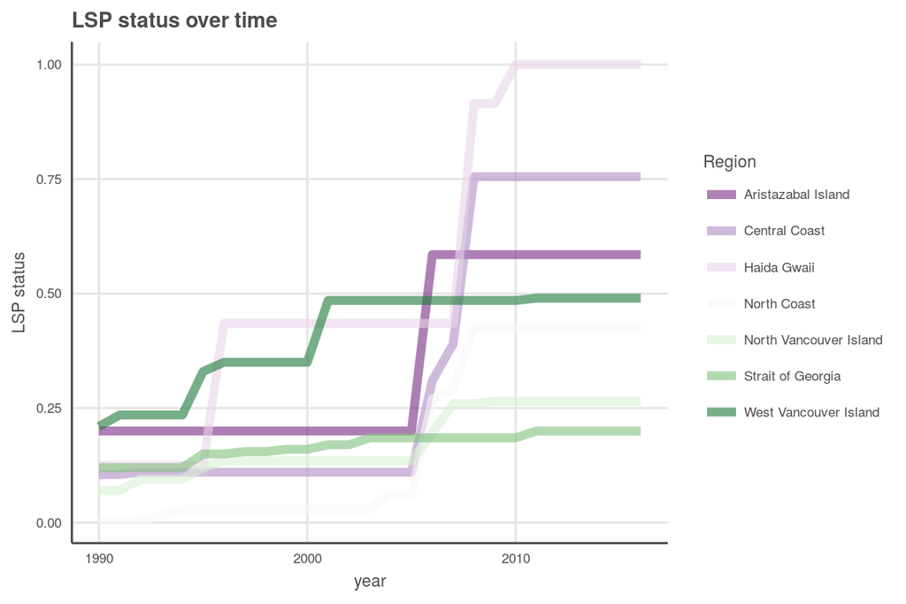

```r
library(ggplot2)
library(plotly)

lsp_status_trend_summary <- read_csv(file.path(dir_goal, 'output', 'lsp_status_trend.csv'))

status_ts_plot <- ggplot(lsp_status_trend_summary %>%
                           filter(!is.na(year)),
                         aes(x = year, y = lsp_status, color = rgn_name, group = rgn_name)) +
  ggtheme_plot +
  geom_line(size = 2, alpha = .6) +
  scale_colour_brewer(palette = 'PRGn') +
  labs(x = 'year',
       y = 'LSP status',
       title = 'LSP status over time',
       color = 'Region')

print(status_ts_plot)
```

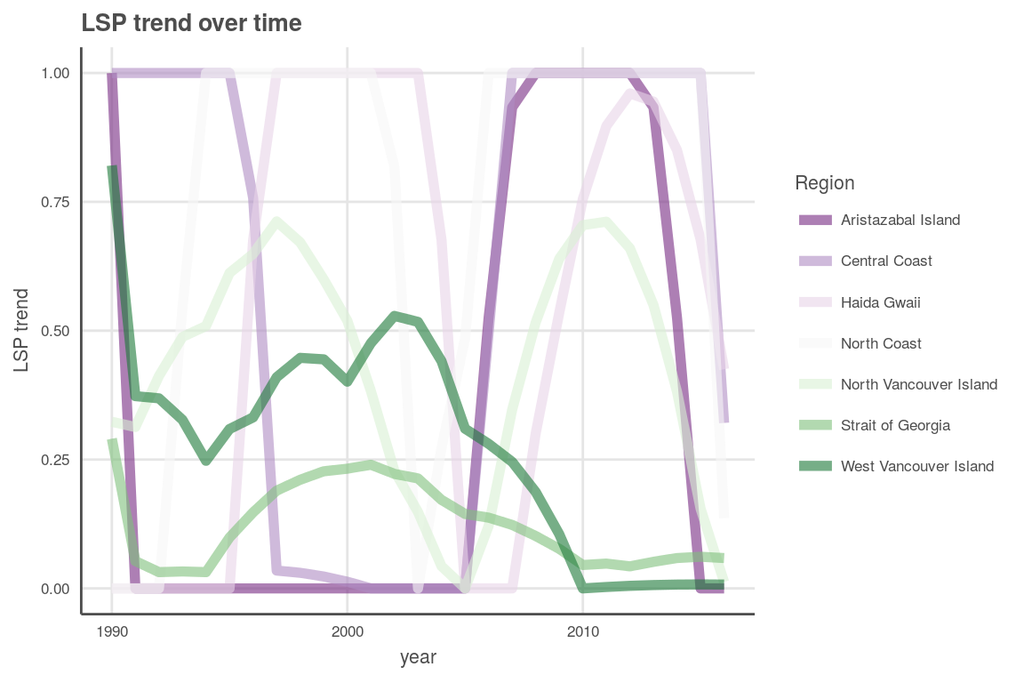

```r
trend_ts_plot <- ggplot(lsp_status_trend_summary %>%
                           filter(!is.na(year) &!is.na(lsp_trend)),
                         aes(x = year, y = lsp_trend, color = rgn_name, group = rgn_name)) +
  ggtheme_plot +
  geom_line(size = 2, alpha = .6) +
  scale_colour_brewer(palette = 'PRGn') +
  labs(x = 'year',
       y = 'LSP trend',
       title = 'LSP trend over time',
       color = 'Region')

print(trend_ts_plot)
```

```r
prov_wrapup(commit_outputs = FALSE)
```

# 5 Provenance

- *Run ID: 6 (a997103); run tag: “standard run”*
- *Run elapsed time: 25.729 seconds; run memory usage: 6018.3 MB*
- *System info:*
  - *System: Linux, Release: 4.4.0-57-generic. Machine: x86_64. User: ohara.*
  - *R version: R version 3.3.2 (2016-10-31), Platform: x86_64-pc-linux-gnu, Running under: Ubuntu 14.04.5 LTS.*
  - *Attached base packages: stats, graphics, grDevices, utils, datasets, methods, base*
  - *Other attached packages: plotly_4.5.2, provRmd_0.1.1, stringr_1.1.0, RColorBrewer_1.1-2, dplyr_0.5.0, purrr_0.2.2, readr_1.0.0, tidyr_0.6.0, tibble_1.2, ggplot2_2.2.0, tidyverse_1.0.0, here_0.0-5, raster_2.5-8, rgdal_1.2-4, rgeos_0.3-20, maptools_0.8-39, sp_1.2-3*

[figure not shown]

| sequence | file_name | parent_chunk | file_dir | filetype | uncomm_chgs | commit_hash_short |
| --- | --- | --- | --- | --- | --- | --- |
| 0 | goal_prep_lsp.Rmd | unnamed-chunk-3 | ~/github/ohibc/prep/lsp/v2017 | parent_script | True | c91d889 |
| 0 | goal_prep_lsp.Rmd#combine_inland_and_offshore | combine_inland_and_offshore | ~/github/ohibc/prep/lsp/v2017 | parent_chunk | True | c91d889 |
| 0 | goal_prep_lsp.Rmd#estimate_status_and_trend_by_year | estimate_status_and_trend_by_year | ~/github/ohibc/prep/lsp/v2017 | parent_chunk | True | c91d889 |
| 0 | goal_prep_lsp.Rmd#lsp_zonal_stats | lsp_zonal_stats | ~/github/ohibc/prep/lsp/v2017 | parent_chunk | True | c91d889 |
| 0 | goal_prep_lsp.Rmd#rasterize_WDPA_and_PEP | rasterize_WDPA_and_PEP | ~/github/ohibc/prep/lsp/v2017 | parent_chunk | True | c91d889 |
| 0 | goal_prep_lsp.Rmd#setup | setup | ~/github/ohibc/prep/lsp/v2017 | parent_chunk | True | c91d889 |
| 0 | goal_prep_lsp.Rmd#set_up_BC_WDPA_polygons | set_up_BC_WDPA_polygons | ~/github/ohibc/prep/lsp/v2017 | parent_chunk | True | c91d889 |
| 0 | goal_prep_lsp.Rmd#spp_plot_scores_over_time | spp_plot_scores_over_time | ~/github/ohibc/prep/lsp/v2017 | parent_chunk | True | c91d889 |
| 0 | goal_prep_lsp.Rmd#summarize_zonal_stats | summarize_zonal_stats | ~/github/ohibc/prep/lsp/v2017 | parent_chunk | True | c91d889 |
| 0 | goal_prep_lsp.Rmd#unnamed-chunk-3 | unnamed-chunk-3 | ~/github/ohibc/prep/lsp/v2017 | parent_chunk | True | c91d889 |

[output cut: 25 more lines]